# CURSO DE ACTUALIZACION EN ESTADISTICA

#### Profesor: Dr. José Manuel MAGALLANES, Ph.D

## Sesión 3:

## **Representación Gráfica de la Información**

Las gráficas nos permiten informarnos sobre:

- Si los valores que la variable toma son similares o hay valores sobresalientes.
- Si hay algun patrón o no.
- Si hay valores atípicos.

Las gráficas de la variables categóricas (nominales y ordinales) usan las tablas de frecuencia. Las variables numéricas no necesitan las tablas de frecuencia, pero pueden ser usadas en algunos casos.

### Parte 1. **Variable Nominales**

Las variables nominales se grafican desde las tablas de frecuencia.

```r
LINK='https://docs.google.com/spreadsheets/d/e/2PACX-1vSKuD4fkPOCgoRhefu9cDLzKJe-tkZ8V0EDPihgr2B6PZK3j-MGAfcSyNRQ91hzhuEh_iCebo1-8DWu/pub?gid=775750542&single=true&output=csv'
mineria=read.csv(LINK,stringsAsFactors = F)
```

Veamos nuestras variables:

```r
str(mineria)
```

```
## 'data.frame':    31 obs. of  3 variables:
##  $ Mina   : chr  "Las Bambas" "Las Bambas" "Las Bambas" "Las Bambas" ...
##  $ REGION : chr  "Apurímac" "Apurímac" "Apurímac" "Apurímac" ...
##  $ Mineral: chr  "COBRE" "ZINC" "PLATA" "ORO" ...
```

La función **str()** nos mostró los tipo de datos. Usemos nuevamente la variable *Mineral*:

```r
table(mineria$Mineral)
```

```
##
##    COBRE DIAMANTE   HIERRO      ORO    PLATA     ZINC
##       18        1        2        7        2        1
```

Transformemos esa **tabla** en un **data frame**, lo que facilita su tratamiento:

```r
#tabla anterior
NomTabla=table(mineria$Mineral)

#recuperando valores
Nombres=names(NomTabla)
conteo=as.vector(NomTabla)
porcentajes=as.vector(prop.table(conteo))

#conviertiendo a dataFrame
NomDf=data.frame(var=Nombres,abs=conteo,rel=porcentajes)

#resultado
NomDf
```

```
##        var abs        rel
## 1    COBRE  18 0.58064516
## 2 DIAMANTE   1 0.03225806
## 3   HIERRO   2 0.06451613
## 4      ORO   7 0.22580645
## 5    PLATA   2 0.06451613
## 6     ZINC   1 0.03225806
```

La misma tabla la usamos para graficar usando la biblioteca **ggplot2**:

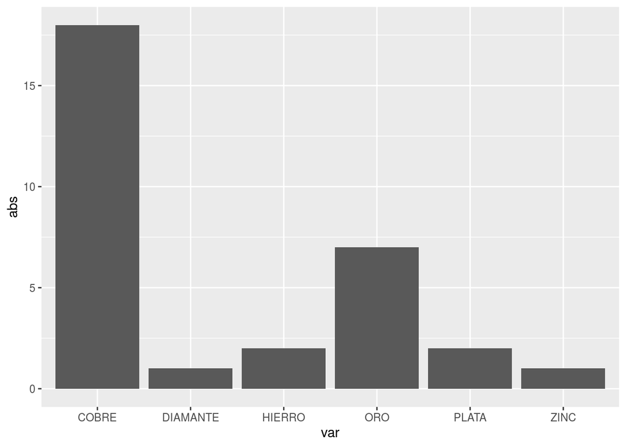

```r
library(ggplot2)

base=ggplot(NomDf, aes(x=var,y=abs))
barraNom= base + geom_bar(stat = 'identity')

#veamos
barraNom
```

Podemos añadir los titulos así:

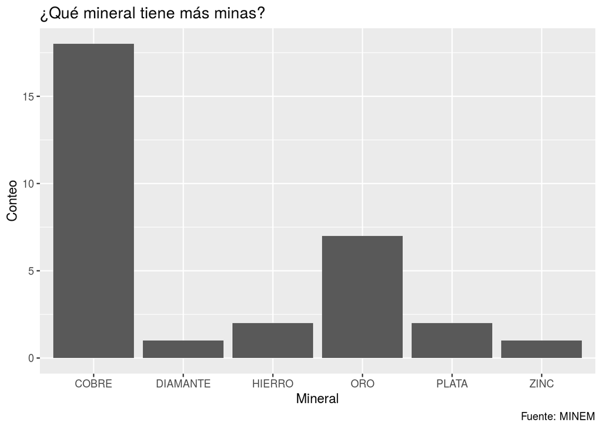

```r
text1="¿Qué mineral tiene más minas?"
text2="Mineral"
text3="Conteo"
text4="Fuente: MINEM"

barraNom1= barraNom + labs(title=text1,
                      x =text2,
                      y = text3,
                      caption = text4)
barraNom1
```

Podríamos decorar un poco:

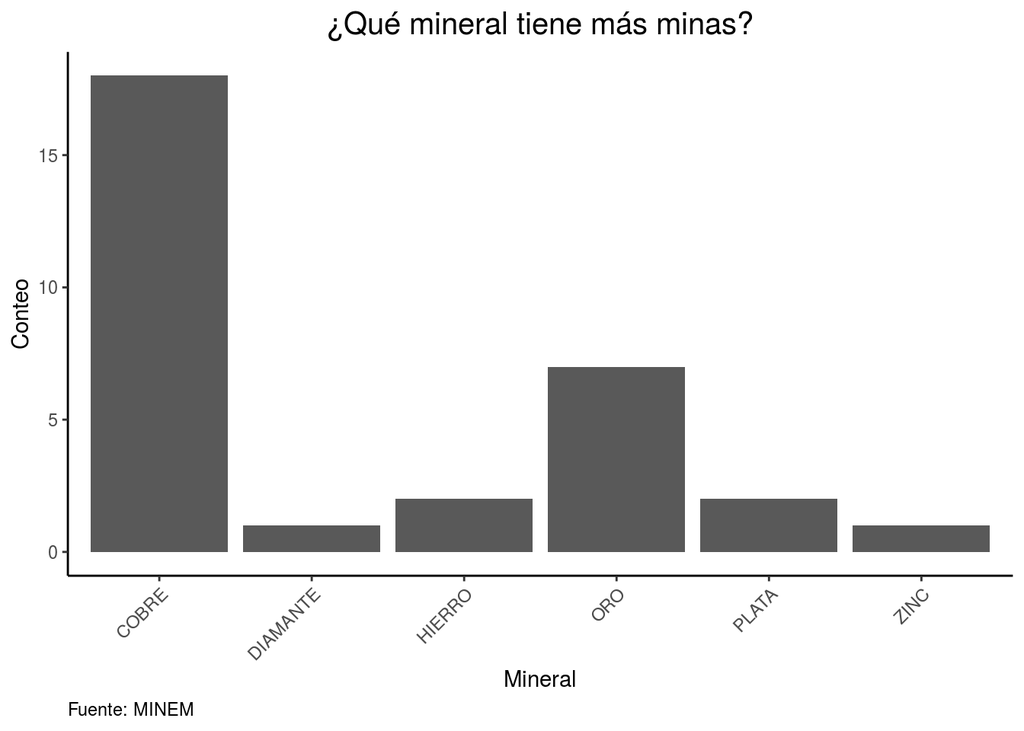

```r
barraNom1 + theme_classic() +
            theme(plot.title = element_text(hjust = 0.5,size=15), # centrar y agrandar
                  plot.caption = element_text(hjust = 0), # a la derecha
                  axis.text.x = element_text(angle=45,hjust = 1)) # angulo
```

Para crear el gráfico de Pareto solo necesitamos la biblioteca **ggQC**, la cual llama a la función **stat_pareto()**:

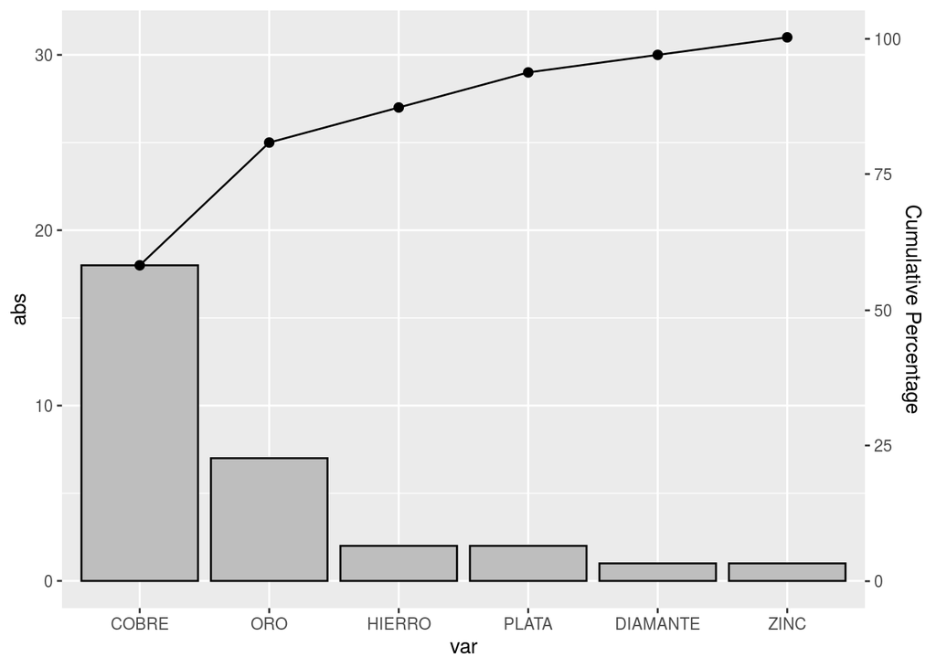

```r
library(ggQC)

base + stat_pareto(bars.fill = 'gray')
```

### Parte 2. Variables Ordinales

Veamos otros datos:

```r
link2='https://docs.google.com/spreadsheets/d/e/2PACX-1vSKuD4fkPOCgoRhefu9cDLzKJe-tkZ8V0EDPihgr2B6PZK3j-MGAfcSyNRQ91hzhuEh_iCebo1-8DWu/pub?gid=1869012038&single=true&output=csv'

accidentes=read.csv(link2, stringsAsFactors = F)
```

Las columnas y sus tipos son:

```r
str(accidentes)
```

```
## 'data.frame':    33 obs. of  10 variables:
##  $ EMPRESA    : chr  "Volcan" "Buenaventura" "Ananea" "Atacocha" ...
##  $ a2000      : int  4 2 0 2 4 2 1 3 2 0 ...
##  $ a2001      : int  12 3 2 6 2 1 3 0 1 2 ...
##  $ a2002      : int  0 4 8 2 0 3 3 3 1 2 ...
##  $ a2003      : int  5 3 0 1 4 3 4 2 3 6 ...
##  $ a2004      : int  3 1 1 1 2 4 3 1 3 2 ...
##  $ a2005      : int  6 7 5 4 2 3 2 3 2 0 ...
##  $ a2006      : int  12 3 4 3 2 0 0 2 1 1 ...
##  $ Responsable: chr  "Contrata" "Contrata" "Contrata" "Contrata" ...
##  $ Tama       : chr  "Grande" "Mediana" "Pequeña" "Mediana" ...
```

La última columna representa tamaño del proyecto, la columna *Tama*:

```r
table(accidentes$Tama)
```

```
##
##  Grande Mediana Pequeña
##       6      25       2
```

Este es un claro ejemplo de variable **ordinal**. En este caso, un proyecto podría pasar por alguno de estos niveles. Por defecto, *R* presenta la tabla en orden alfabético. Aquí sí debemos transformar la variable en el tipo que corresponde, y a la vez indicar el orden correcto:

```r
accidentes$Tama=factor(accidentes$Tama,
                       levels=c('Pequeña','Mediana','Grande'), # orden correcto
                       ordered = T) # T (TRUE) para ordinal
```

Hagamos la tabla de frecuencias para producir el gráfico:

```r
# tabla simple anterior, pero ya "ordinalizada":
OrdTabla=table(accidentes$Tama)

#recuperando valores
Nombres=names(OrdTabla)
conteo=as.vector(OrdTabla)
porcentajes=as.vector(prop.table(conteo))

# calculando acumulaciones
cum_conteo=cumsum(conteo) # suma de conteo
cum_porcentajes=cumsum(porcentajes) # suma de conteo en %

#creando DF
OrdDf=data.frame(var=Nombres,
                    abs=conteo,rel=porcentajes,
                    abs_acu=cum_conteo,rel_acu=cum_porcentajes,stringsAsFactors = F)
#resultado
OrdDf
```

```
##       var abs        rel abs_acu    rel_acu
## 1 Pequeña   2 0.06060606       2 0.06060606
## 2 Mediana  25 0.75757576      27 0.81818182
## 3  Grande   6 0.18181818      33 1.00000000
```

La misma tabla la usamos para graficar usando **ggplot2**:

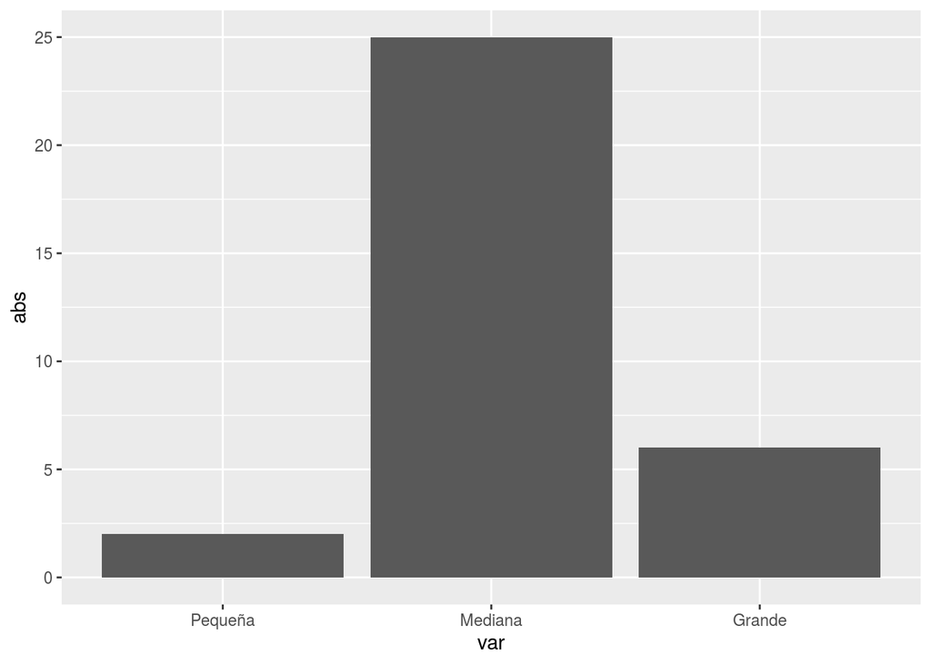

```r
base= ggplot(OrdDf, aes(x=var,y=abs)) +
      scale_x_discrete(limits=Nombres) # indicando orden
barraOrd= base + geom_bar(stat = 'identity')

#veamos
barraOrd
```

### Parte 3. Variables Numéricas

En la data anterior tuvimos la cantidad de accidentes por año, del 2000 al 2006. Sumemos esos años:

```r
# comando "rowSums"
# aplicandolo de la columna 2 hasta la 8 inclusive
accidentes$totalAcci=rowSums(accidentes[,c(2:8)])

#este es el resultado de la columna nueva
accidentes$totalAcci
```

```
##  [1] 42 23 20 19 16 16 16 14 13 13 13 12 10 10 10  8  8  8  7  7  7  6  6
## [24]  6  5  5  5  5  5  5  5  5  5
```

Esa variable nueva, la debemos convertir en intervalos. R cuenta con la función **cut()**, que permite crear intervalos; lo unico que necesita esa función es que se le diga cuanto intervalos se necesitan, para lo cual usariamos la recomendación de Sturgesm usando la función **nclass.Sturges**:

```r
intervalos=cut(accidentes$totalAcci, breaks=nclass.Sturges(accidentes$totalAcci),
               ordered_result = T)
intervalos
```

```
##  [1] (36.7,42]   (20.9,26.1] (15.6,20.9] (15.6,20.9] (15.6,20.9]
##  [6] (15.6,20.9] (15.6,20.9] (10.3,15.6] (10.3,15.6] (10.3,15.6]
## [11] (10.3,15.6] (10.3,15.6] (4.96,10.3] (4.96,10.3] (4.96,10.3]
## [16] (4.96,10.3] (4.96,10.3] (4.96,10.3] (4.96,10.3] (4.96,10.3]
## [21] (4.96,10.3] (4.96,10.3] (4.96,10.3] (4.96,10.3] (4.96,10.3]
## [26] (4.96,10.3] (4.96,10.3] (4.96,10.3] (4.96,10.3] (4.96,10.3]
## [31] (4.96,10.3] (4.96,10.3] (4.96,10.3]
## 7 Levels: (4.96,10.3] < (10.3,15.6] < (15.6,20.9] < ... < (36.7,42]
```

Una simple tabla puede mostrar lo que se tiene:

```r
table(intervalos)
```

```
## intervalos
## (4.96,10.3] (10.3,15.6] (15.6,20.9] (20.9,26.1] (26.1,31.4] (31.4,36.7]
##          21           5           5           1           0           0
##   (36.7,42]
##           1
```

Y como data frame:

```r
intervTabla=table(intervalos)

Nombres=names(intervTabla)
conteo=as.vector(intervTabla)
porcentajes=as.vector(prop.table(conteo))

cum_conteo=cumsum(conteo) # suma de conteo
cum_porcentajes=cumsum(porcentajes) # suma de conteo en %


NumDf=data.frame(var=Nombres,
                 abs=conteo,rel=porcentajes,
                 abs_acu=cum_conteo,rel_acu=cum_porcentajes,
                 stringsAsFactors = F)

NumDf
```

```
##           var abs        rel abs_acu   rel_acu
## 1 (4.96,10.3]  21 0.63636364      21 0.6363636
## 2 (10.3,15.6]   5 0.15151515      26 0.7878788
## 3 (15.6,20.9]   5 0.15151515      31 0.9393939
## 4 (20.9,26.1]   1 0.03030303      32 0.9696970
## 5 (26.1,31.4]   0 0.00000000      32 0.9696970
## 6 (31.4,36.7]   0 0.00000000      32 0.9696970
## 7   (36.7,42]   1 0.03030303      33 1.0000000
```

De aquí:

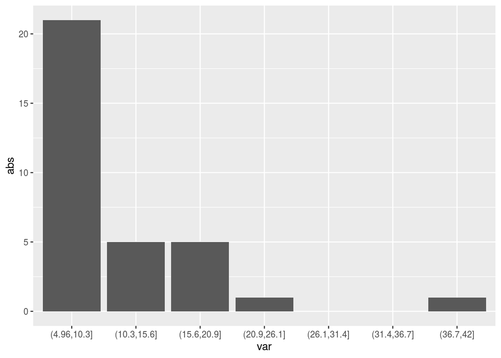

```r
base=ggplot(NumDf, aes(x=var,y=abs)) + scale_x_discrete(limits=Nombres)
NumBarra= base + geom_bar(stat = 'identity')

#veamos
NumBarra
```

También funciona para Pareto:

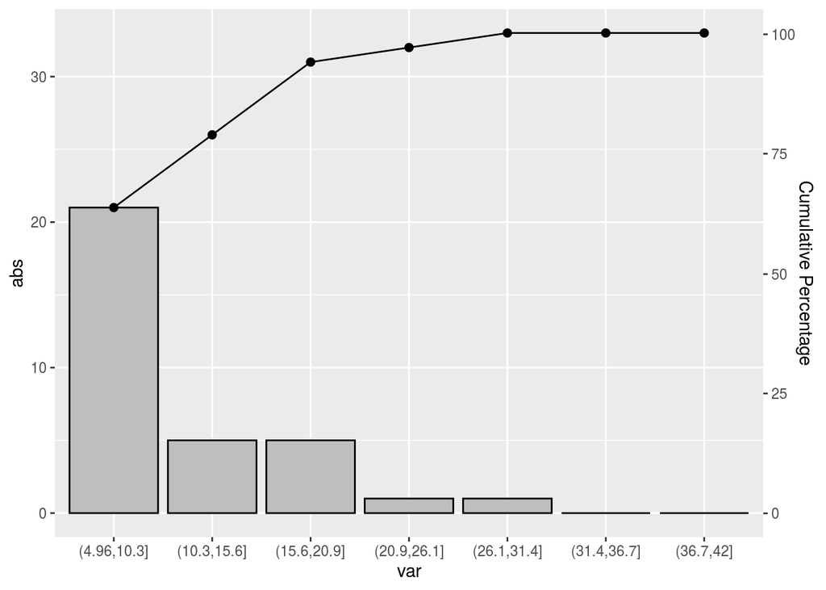

```r
base + stat_pareto(bars.fill = 'gray')
```

El gráfico histograma no necesita que le calculemos intervalos en ggplot, pues éste lo calcula de inmediato para toda vaiable de este tipo:

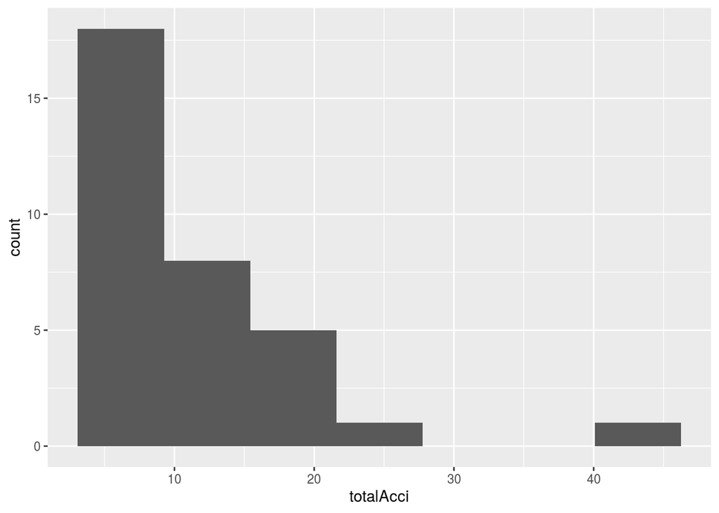

```r
base=ggplot(accidentes,aes(x=totalAcci))
histOrd= base + geom_histogram(bins=7)
histOrd
```

Al histograma le podemos añadir su polígono de frecuecias:

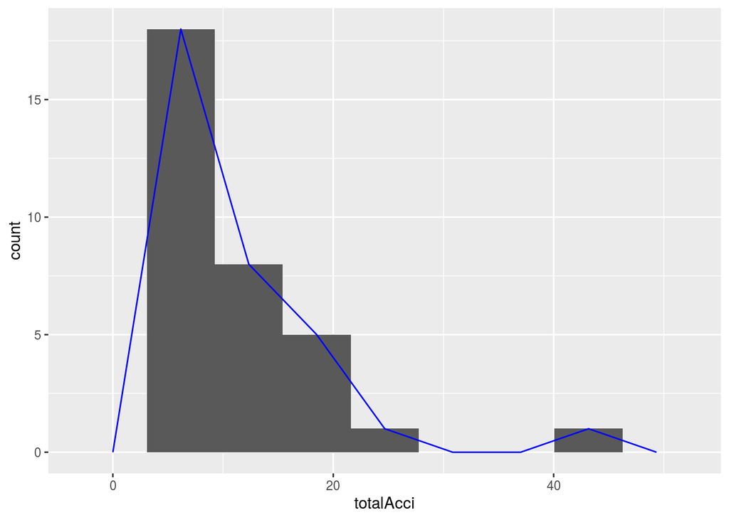

```r
histOrd1= histOrd + geom_freqpoly(bins=7,col='blue')
histOrd1
```

Y su ojiva de dataos acumulados:

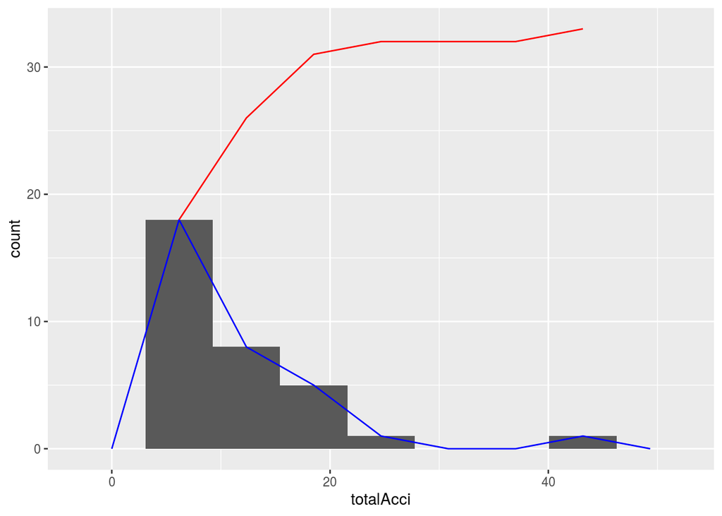

```r
histOrd1  + stat_bin(aes(y=cumsum(..count..)),geom="line",bins=7,col='red')
```

Otro gráfico importante es al **diagrama de cajas y bigotes**:

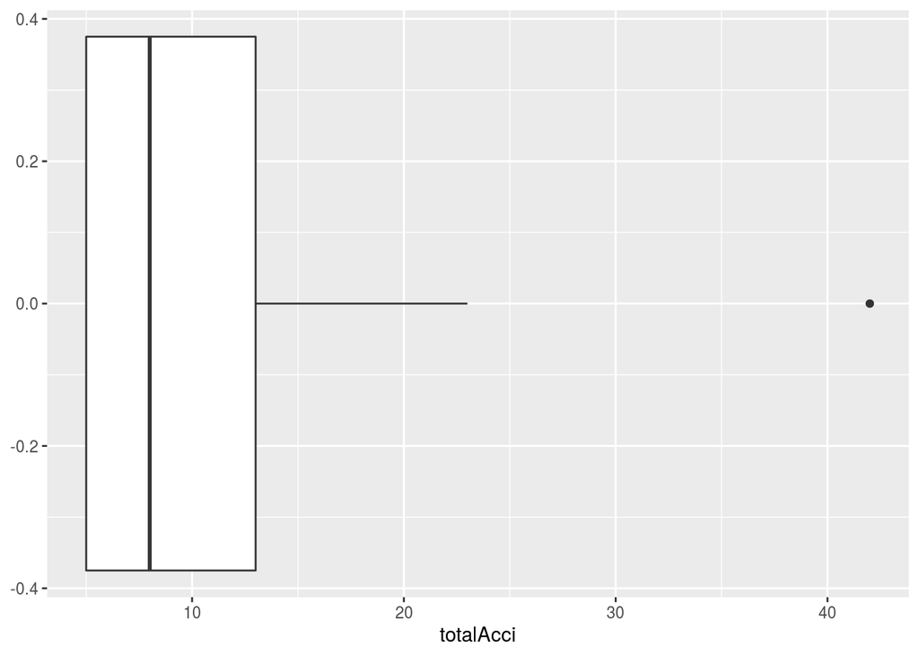

```r
base=ggplot(accidentes,aes(y=totalAcci))
base + geom_boxplot() + coord_flip()
```

Por ahora, este gráfico nos permite confirmar que tener más de 40 accidentes es muy atípico. Veremos más detalles de este gráfico luego de las sesiones sobre medidas estadísticas.

**Ejercicio:**

Utilice sus datos y prepare los gráficos que correspondan.

[Volver al programa del curso](https://coursesandtutorials.github.io/Estadistica/)